# Hayman Fire Recovery

MJ Carlson

February 07, 2022

```r
library(tidyverse)
library(tidyr)
library(ggthemes)
library(lubridate)
library(gridExtra)

# Now that we have learned how to munge (manipulate) data
# and plot it, we will work on using these skills in new ways

knitr::opts_knit$set(root.dir='..')
```

```r
####-----Reading in Data and Stacking it ----- ####
#Reading in files
files <- list.files('data',full.names=T)


#Read in individual data files
ndmi <- read_csv(files[1]) %>%
  rename(burned=2,unburned=3) %>%
  mutate(data='ndmi')


ndsi <- read_csv(files[2]) %>%
  rename(burned=2,unburned=3) %>%
  mutate(data='ndsi')

ndvi <- read_csv(files[3])%>%
  rename(burned=2,unburned=3) %>%
  mutate(data='ndvi')

# Stack as a tidy dataset
full_long <- rbind(ndvi,ndmi,ndsi) %>%
  gather(key='site',value='value',-DateTime,-data) %>%
  filter(!is.na(value))
```

## Question 1)

What is the correlation between NDVI and NDMI? - here I want you to convert the full_long dataset in to a wide dataset using the function “spread” and then make a plot that shows the correlation s a function of if the site was burned or not (x axis should be ndmi) You should exclude winter months and focus on summer months

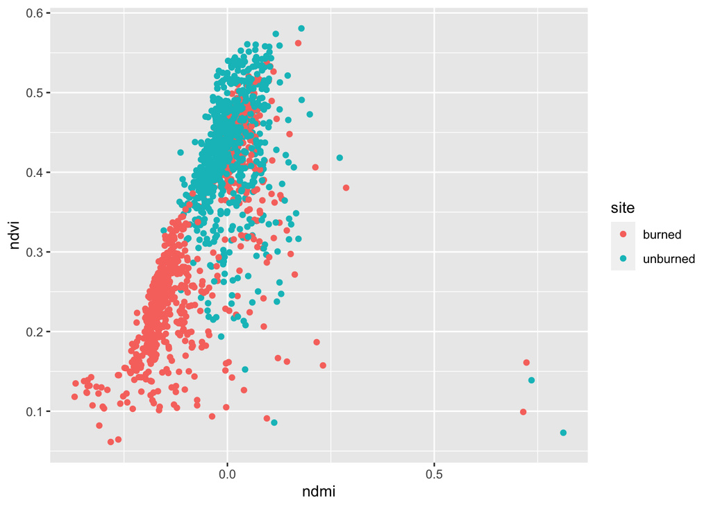

```r
full_wide=full_long%>%
  spread(data, value)%>%
  filter_if(is.numeric,all_vars(!is.na(.)))

full_wide_xwinter<-full_wide%>%
  mutate(month=month(DateTime))%>%
  filter(month %in% c(5, 6, 7, 8, 9))


ggplot(full_wide_xwinter, aes(x=ndmi, y=ndvi, color=site))+
  geom_point()
```

There is a strong positive correlation between NDVI and NDMI for both burned and unburned sites. The burned sights generally have a lower NDVI which is to be expected due to the reduced amount of vegetation as a result of the burn.

## Question 2

2. What is the correlation between average NDSI (normalized snow index) for January - April and average NDVI for June-August? In other words, does the previous year’s snow cover influence vegetation growth for the following summer?

```r
#ndsi winter data frame
ndsi_annual<-full_wide%>%
  mutate(month=month(DateTime))%>%
  mutate(year=year(DateTime))%>%
  filter(month %in% c(1,2,3,4))%>%
  subset(., select= -c(ndvi,ndmi))%>%
  group_by(site, year)%>%
  summarize(mean_ndsi=mean(ndsi))

#ndvi summer data frame
ndvi_annual<-full_wide%>%
  mutate(month=month(DateTime))%>%
  mutate(year=year(DateTime))%>%
  filter(month %in% c(6,7,8))%>%
  subset(., select = -c(ndsi,ndmi))%>%
  group_by(site, year)%>%
  summarize(mean_ndvi=mean(ndvi))

#combine data frames
combined<-inner_join(ndvi_annual,ndsi_annual)

#correlation
cor(combined$mean_ndsi, combined$mean_ndvi)
```

```
## [1] 0.1803564
```

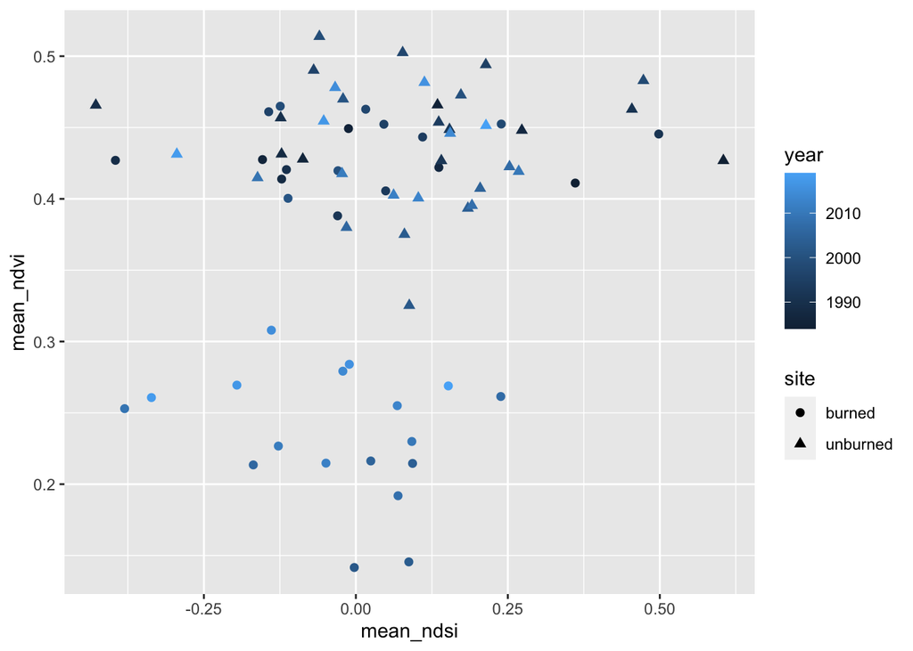

```r
#correlation plot
ggplot(combined, aes(x=mean_ndsi, y=mean_ndvi, color=year, shape=site))+
  geom_point(size=2)
```

There is minimal correlation between the previous years snowfall and vegetation growth. The correlation coefficient is 0.18, meaning that the positive correlation is close to 0 or nearly no linear relationship.

## Q3

How is the snow effect from question 2 different between pre- and post-burn and burned and unburned?

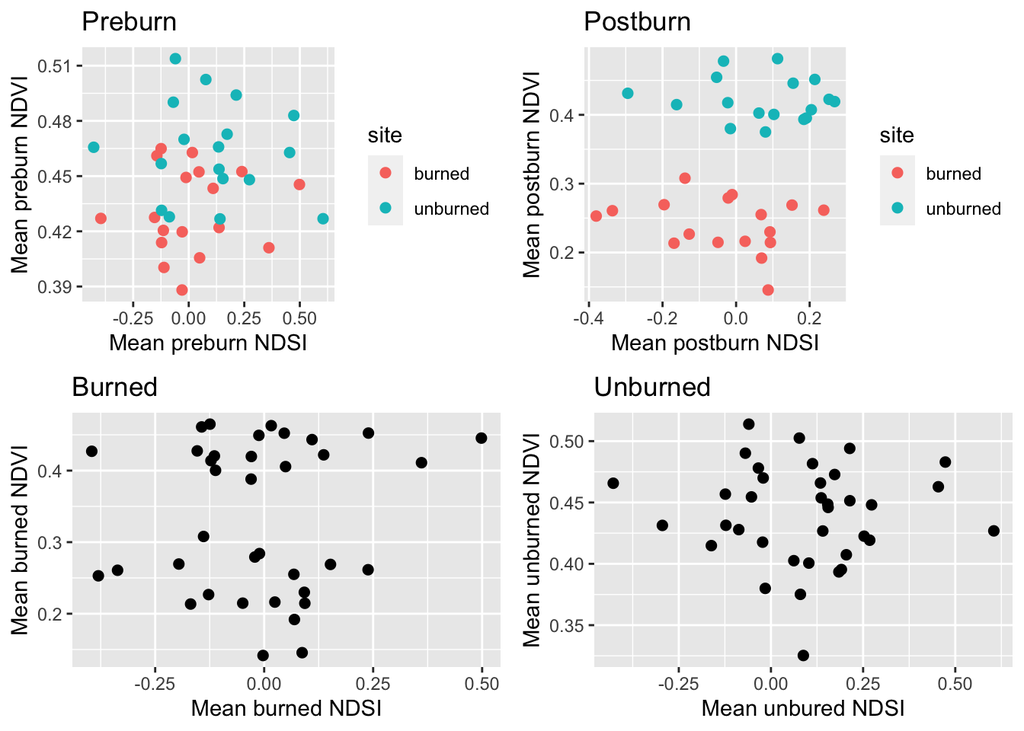

```r
#pre and post burn
preburn<-c(1984:2001)
postburn<-c(2003:2019)

#preburn
#preburn annual ndsi
preburn_annualndsi<-full_wide[c(1,2,4)] %>%
  mutate(month=month(DateTime))%>%
  mutate(year=year(DateTime))%>%
  filter(month %in% c(1,2,3,4))%>%
  filter(year %in% preburn)%>%
  group_by(site, year)%>%
  summarize(mean_preburnndsi=mean(ndsi))

#preburn annual ndvi
preburn_annualndvi<-full_wide[c(1,2,5)] %>%
  mutate(month=month(DateTime))%>%
  mutate(year=year(DateTime))%>%
  filter(month %in% c(6,7,8))%>%
  filter(year %in% preburn)%>%
  group_by(site, year)%>%
  summarize(mean_preburnndvi=mean(ndvi))

#combine pre burn
combinepre<-inner_join(preburn_annualndsi,preburn_annualndvi)

#correlation pre burn
cor_preburn<-cor(combinepre$mean_preburnndsi, combinepre$mean_preburnndvi)

#plot combine pre burn
p1<-ggplot(combinepre, aes(x=mean_preburnndsi, y=mean_preburnndvi, color=site))+
  geom_point(size=2)+
  labs(title="Preburn",
       x="Mean preburn NDSI",
       y= "Mean preburn NDVI")

#postburn
#postburn annual ndsi
postburn_annualndsi<-full_wide[c(1,2,4)] %>%
  mutate(month=month(DateTime))%>%
  mutate(year=year(DateTime))%>%
  filter(month %in% c(1,2,3,4))%>%
  filter(year %in% postburn)%>%
  group_by(site, year)%>%
  summarize(mean_postburnndsi=mean(ndsi))

#postburn annual ndvi
postburn_annualndvi<-full_wide[c(1,2,5)] %>%
  mutate(month=month(DateTime))%>%
  mutate(year=year(DateTime))%>%
  filter(month %in% c(6,7,8))%>%
  filter(year %in% postburn)%>%
  group_by(site, year)%>%
  summarize(mean_postburnndvi=mean(ndvi))

#combine post burn
combinepost<-inner_join(postburn_annualndsi,postburn_annualndvi)

#correlation post burn
cor_postburn<-cor(combinepost$mean_postburnndsi, combinepost$mean_postburnndvi)

#plot combine post burn
p2<-ggplot(combinepost, aes(x=mean_postburnndsi, y=mean_postburnndvi, color=site))+
  geom_point(size=2)+
   labs(title="Postburn",
       x="Mean postburn NDSI",
       y= "Mean postburn NDVI")

#burned and unburned correlation
#burned
#burned annual ndsi
burned_annualndsi<-full_wide[c(1,2,4)] %>%
  mutate(month=month(DateTime))%>%
  mutate(year=year(DateTime))%>%
  filter(month %in% c(1,2,3,4))%>%
  filter(site %in% "burned")%>%
  group_by(site, year)%>%
  summarize(mean_burnndsi=mean(ndsi))

#burned annual ndvi
burned_annualndvi<-full_wide[c(1,2,5)] %>%
  mutate(month=month(DateTime))%>%
  mutate(year=year(DateTime))%>%
  filter(month %in% c(6,7,8))%>%
  filter(site %in% "burned")%>%
  group_by(site, year)%>%
  summarize(mean_burnndvi=mean(ndvi))

#combine burned
combineburned<-inner_join(burned_annualndsi,burned_annualndvi)

#correlation burned
cor_burned<-cor(combineburned$mean_burnndsi, combineburned$mean_burnndvi)

#plot combine burn
p3<-ggplot(combineburned, aes(x=mean_burnndsi, y=mean_burnndvi))+
  geom_point(size=2)+
   labs(title="Burned",
       x="Mean burned NDSI",
       y= "Mean burned NDVI")

#unburned
#unburned annual ndsi
unburned_annualndsi<-full_wide[c(1,2,4)] %>%
  mutate(month=month(DateTime))%>%
  mutate(year=year(DateTime))%>%
  filter(month %in% c(1,2,3,4))%>%
  filter(site %in% "unburned")%>%
  group_by(site, year)%>%
  summarize(mean_unburnndsi=mean(ndsi))

#unburned annual ndvbi
unburned_annualndvi<-full_wide[c(1,2,5)] %>%
  mutate(month=month(DateTime))%>%
  mutate(year=year(DateTime))%>%
  filter(month %in% c(6,7,8))%>%
  filter(site %in% "unburned")%>%
  group_by(site, year)%>%
  summarize(mean_unburnndvi=mean(ndvi))

#combine unburned
combineunburned<-inner_join(unburned_annualndsi,unburned_annualndvi)

#correlation unburned
cor_unburned<-cor(combineunburned$mean_unburnndsi, combineunburned$mean_unburnndvi)

#plot combine unburn
p4<-ggplot(combineunburned, aes(x=mean_unburnndsi, y=mean_unburnndvi))+
  geom_point(size=2)+
   labs(title="Unburned",
       x="Mean unbured NDSI",
       y= "Mean unburned NDVI")

grid.arrange(p1, p2, p3, p4)
```

```r
cor_preburn
```

```
## [1] 0.09100615
```

```r
cor_postburn
```

```
## [1] 0.24394
```

```r
cor_burned
```

```
## [1] 0.08700527
```

```r
cor_unburned
```

```
## [1] -0.03100231
```

There is no correlation between snow and vegetation for preburn, burned and unburned sites. There is a slight positive linear correlation between snow and vegetation for postburn sites with a value of 0.24.

## Question 4

What month is the greenest month on average?

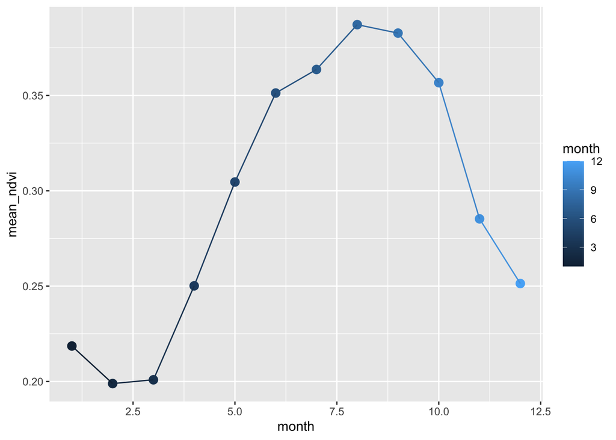

```r
ndvi_month<-full_wide[c(1,2,5)]%>%
  mutate(month=month(DateTime))%>%
  mutate(year=year(DateTime))%>%
  group_by(month)%>%
  summarize(mean_ndvi=mean(ndvi))

ggplot(ndvi_month, aes(x=month, y=mean_ndvi, color=month))+
  geom_point(size=3)+
  geom_line()
```

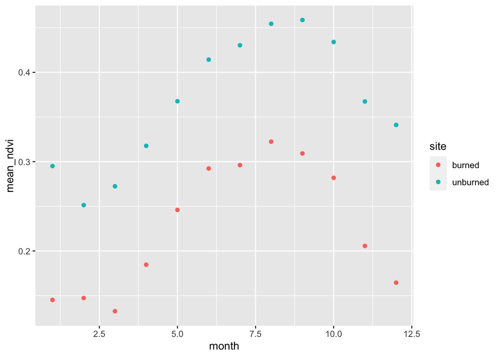

```r
ndvi_month2<-full_wide[c(1,2,5)]%>%
  mutate(month=month(DateTime))%>%
  mutate(year=year(DateTime))%>%
  group_by(site,month)%>%
  summarize(mean_ndvi=mean(ndvi))

ggplot(ndvi_month2, aes(x=month, y=mean_ndvi, color=site))+
  geom_point()
```

The greenest month on average is August. The greenest month for burned sites is also August but the greenest month for unburned sights is September.

## Question 5)

What month is the snowiest on average?

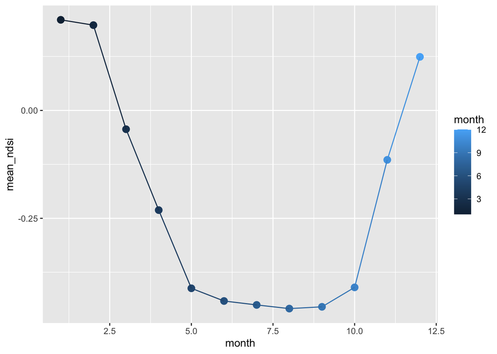

```r
ndsi_month<-full_wide[c(1,2,4)]%>%
  mutate(month=month(DateTime))%>%
  mutate(year=year(DateTime))%>%
  group_by(month)%>%
  summarize(mean_ndsi=mean(ndsi))

ggplot(ndsi_month, aes(x=month, y=mean_ndsi, color=month))+
  geom_point(size=3)+
  geom_line()
```

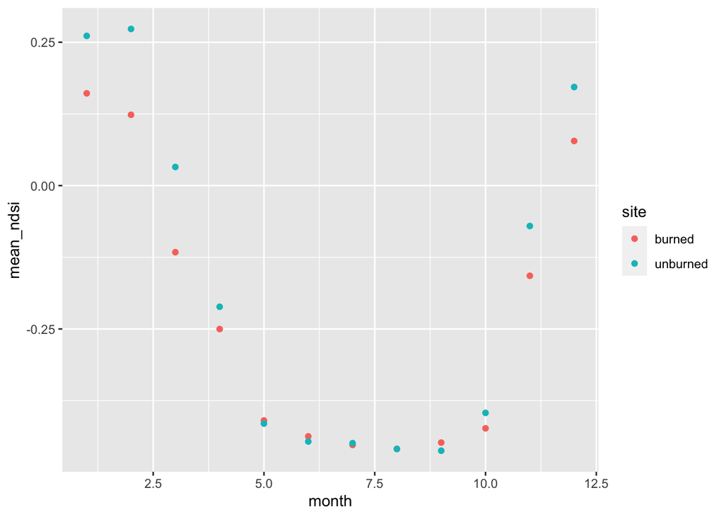

```r
ndsi_month2<-full_wide[c(1,2,4)]%>%
  mutate(month=month(DateTime))%>%
  mutate(year=year(DateTime))%>%
  group_by(site, month)%>%
  summarize(mean_ndsi=mean(ndsi))

ggplot(ndsi_month2, aes(x=month, y=mean_ndsi, color=site))+
  geom_point()
```

The snowiest month on average is January. There is minimal difference in the NDSI between the burned and unburned sites, however, the unburned does have February as the snowiest month.

## Bonus Question: Redo all problems with `spread` and `gather` using modern tidyverse syntax.

## Bonus Question: Use Climage Engine to pull the same data for the assignment, but updated with 2020/2021 data.